# Social Proximity Zipcode

To do:

*add maps* - ask Kushagra **connect if sci > threshold** plot map with thickness of lines being the sci (thicker = higher sci) *provide connectivity for census tract* - Zitao and Yanrong **produce sci for census tract** **weighting by proportion of zipcode in a census tract** **create meta data** - Erin *put in jupyter notebook* *clean it up*

Social Networks can be a significant factor in understanding the dynamics of various aspects of different fields such as social,economical and public health. In order to substantiate the intensity of social network between individuals Bailey et al proposed a relative frequency of Friendship links between different geographical unit called as Social Connectedness Index. Due to the nature of its relative frequency a comparison between the intensity of social ties across different locations can now be possible. Further Kulcher et al proposed another measure understanding the social influence of alters on ego called social proximity. This markdown file is a guide for other researchers who would want to make use of Social Proximity in there research.

```r
library(tidyverse)
```

```r
library(igraph)
library(ggplot2)
library(geodist)
library(zipcodeR)
library(glmnet)
library(pls)
library(leaps)
library(class)
library(tree)
library(readxl)
```

```r
ZIP <- read.table("zcta_zcta_shard1.tsv", header=T, sep="\t")
ZC <- read.csv("zip_code_database.csv")
```

```r
#PA zip code from 15001 to 19612
ZIP_PA <- ZIP %>%
  filter(user_loc %in% 15001:19612 & fr_loc %in% 15001:19614) %>%
  distinct(scaled_sci,.keep_all = TRUE)
```

```r
#Calculate distance
ZIP_PA_DIS <- ZIP_PA %>%
  mutate(zip_distance(user_loc, fr_loc)) %>%
  select(user_loc,fr_loc,scaled_sci,distance)
```

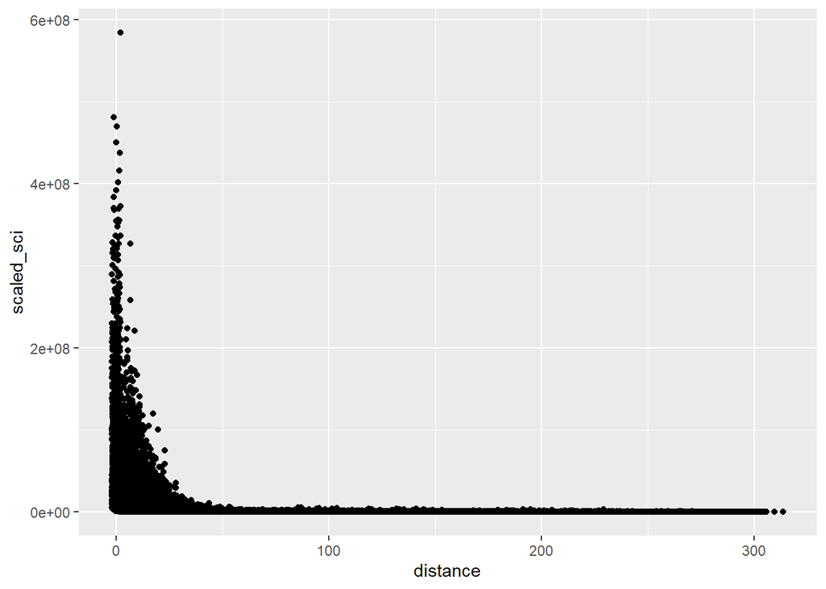

```r
#Plot sci vs. distance
ggplot(ZIP_PA_DIS,aes(distance,scaled_sci)) +
  geom_jitter(height = 2, width = 2)
```

```r
#Add Counties to the data frame

ZC1 <- plyr::rename(ZC, c('zip'='user_loc','county'='county_user'))
ZC2 <- plyr::rename(ZC, c('zip'='fr_loc','county'='county_fr'))

ZC1 <- ZC1 %>%
  select(user_loc,county_user)

ZC2 <- ZC2 %>%
  select(fr_loc,county_fr)

ZIP_PA_DIS <- merge(ZIP_PA_DIS,ZC1, by = 'user_loc')
ZIP_PA_DIS <- merge(ZIP_PA_DIS,ZC2, by = 'fr_loc')
```

```r
# Add Urban/Rural classifications to counties

u_r <- read.csv("urban_rural.csv")

ZIP_PA_DIS <- merge(ZIP_PA_DIS,u_r, by.x = 'county_user', by.y = 'County')
ZIP_PA_DIS <- merge(ZIP_PA_DIS,u_r, by.x = 'county_fr', by.y = 'County')

ZIP_PA_DIS <- plyr::rename(ZIP_PA_DIS, c('U_R.x'='ur_user','U_R.y'='ur_fr'))
```

```r
#Categorize Urban and Rural as 1 and -1 respectively
ZIP_PA_DIS$ur_user[ZIP_PA_DIS$ur_user=="Rural"] = -1
ZIP_PA_DIS$ur_user[ZIP_PA_DIS$ur_user=="Urban"] = 1
ZIP_PA_DIS$ur_fr[ZIP_PA_DIS$ur_fr=="Rural"] = -1
ZIP_PA_DIS$ur_fr[ZIP_PA_DIS$ur_fr=="Urban"] = 1

ZIP_PA_DIS$ur_user <- as.numeric(ZIP_PA_DIS$ur_user)
ZIP_PA_DIS$ur_fr <- as.numeric(ZIP_PA_DIS$ur_fr)

#Create correlation column that tells us if two counties are both rural (-2), both
ZIP_PA_DIS <- ZIP_PA_DIS %>%
  mutate('correlation' = ur_user + ur_fr)

ZIP_PA_DIS$correlation <- as.factor(ZIP_PA_DIS$correlation)
```

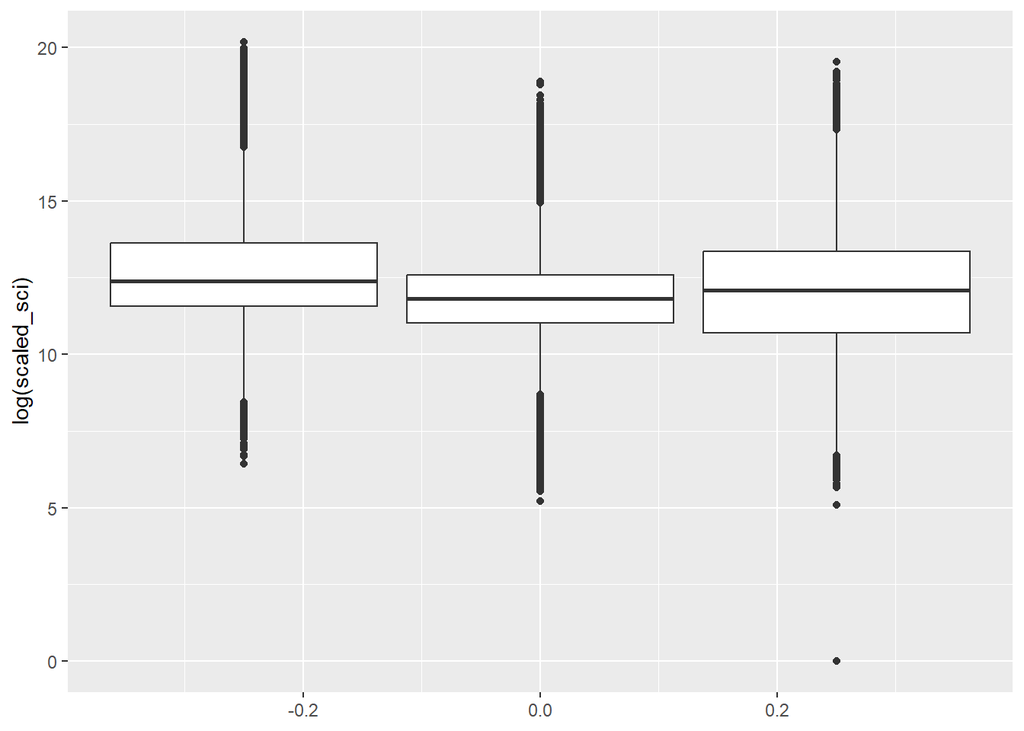

```r
ggplot(ZIP_PA_DIS, aes( group = correlation , y = log(scaled_sci))) +
  geom_boxplot()
```

Now we will import social determinant of health data from: https://www.ahrq.gov/sdoh/data-analytics/sdoh-data.html. We will use 2020 data since the SCI data is from 2020.

```r
df_sdoh<- read_excel("SDOH_2020_ZIPCODE_1_0.xlsx", sheet = 'Data')
```

```r
df_sdoh_pa <- df_sdoh %>% filter(STATE == 'Pennsylvania')
```

After considering each possible predictor, we have selected predictors that seem like they might have helpful information regarding sci.

```r
df_sdoh_pa_selected <- df_sdoh_pa %>% select(3,10, 37, 41, 53, 55, 56, 62, 81, 85, 91, 92, 96, 103, 104, 120, 121, 134, 136, 162, 181, 216, 227, 230, 231, 247, 250, 254, 264, 265, 282, 283, 284, 289, 291, 292, 315, 318)
df_s <- ZIP_PA_DIS
df_s <- df_s[order(as.numeric(rownames(df_s))),,drop=FALSE]
df_s$Count <- (1:nrow(df_s))
df_sdoh_sci_fr <- merge(df_s, df_sdoh_pa_selected, by.x = 'fr_loc', by.y = 'ZIPCODE')
df_sdoh_sci_user <- merge(df_s, df_sdoh_pa_selected, by.x = 'user_loc', by.y = 'ZIPCODE')
df_sdoh_sci_user <-df_sdoh_sci_user[order(df_sdoh_sci_user$Count),,drop=FALSE]
df_sdoh_sci_fr <-df_sdoh_sci_fr[order(df_sdoh_sci_fr$Count),,drop=FALSE]
df_full<- abs(df_sdoh_sci_fr[10:47] - df_sdoh_sci_user[ 10:47])
df_s <- df_s[order(df_s$Count),,drop=FALSE]

#Add respective data from sci data frame
df_full$distance <- df_s$distance
df_full$urbrur <- df_s$correlation
#Take log of scaled_sci, from looking at the graphs of data and then the affects on analysis we decided to transform the scaled_sci
df_full$scaled_sci <- log(df_s$scaled_sci)
df_full$fr_loc <- df_s$fr_loc
df_full$user_loc <- df_s$user_loc
```

```r
#Clean the data a little: Drop NAs. Omit any rows with distance = 0. These are sci pairs within the same zipcode, and won't be able to be predicted from differences. This analysis will need to be done separately.
df_full <- na.omit(df_full)
df_full <- df_full %>% filter(distance > 0)
df_normalized <- df_full
#Let's normalize the data
for (i in 2:39){
  df_normalized[,i]<-((df_full[,i] - min(df_full[,i]))/((max(df_full[,i])-min(df_full[,i]))))
}

#Let's look a little at the correlations before digging in for further analysis
cor(df_normalized$scaled_sci, df_normalized[2:39])
```

```
##      ACS_TOT_POP_US_ABOVE1_ZC ACS_PCT_MALE_ZC ACS_PCT_FOREIGN_BORN_ZC
## [1,]               -0.1677796      0.02908279              -0.1577256
##      ACS_PCT_HH_LIMIT_ENGLISH_ZC ACS_PCT_OTH_LANG_ZC ACS_PCT_SPANISH_ZC
## [1,]                 -0.09365641         -0.09057315        -0.09246645
##      ACS_MEDIAN_AGE_ZC ACS_PCT_ASIAN_ZC ACS_PCT_BLACK_ZC ACS_PCT_HISPANIC_ZC
## [1,]       -0.01685929       -0.1214929       -0.1293077           -0.111471
##      ACS_PCT_MULT_RACE_ZC ACS_PCT_NHPI_ZC ACS_PCT_OTHER_RACE_ZC
## [1,]          -0.02805532     -0.01131862           -0.08180078
##      ACS_PCT_WHITE_ZC ACS_PCT_HH_NO_COMP_DEV_ZC ACS_PCT_HH_SMARTPHONE_ZC
## [1,]       -0.1638764              -0.007759827              -0.04040888
##      ACS_PCT_HH_CELLULAR_ZC ACS_PCT_HH_NO_INTERNET_ZC ACS_PCT_EMPLOYED_ZC
## [1,]            -0.04682732               -0.02237174         -0.01076282
##      ACS_GINI_INDEX_ZC ACS_PER_CAPITA_INC_ZC ACS_PCT_HH_FOOD_STMP_BLW_POV_ZC
## [1,]      -0.002872336           -0.09723591                     -0.05463009
##      ACS_PCT_COLLEGE_ASSOCIATE_DGR_ZC ACS_PCT_BACHELOR_DGR_ZC
## [1,]                      -0.02268459              -0.1086797
##      ACS_PCT_1UP_PERS_1ROOM_ZC ACS_PCT_DIF_STATE_ZC ACS_PCT_HH_ALONE_ABOVE65_ZC
## [1,]               0.007151031          -0.03394976                 0.008972255
##      ACS_PCT_IN_COUNTY_MOVE_ZC ACS_PCT_IN_STATE_MOVE_ZC
## [1,]               -0.03272563                -0.001813
##      ACS_PCT_COMMT_60MINUP_ZC ACS_PCT_DRIVE_2WORK_ZC ACS_PCT_HU_NO_VEH_ZC
## [1,]             -0.009004063             -0.1056908          -0.08284833
##      ACS_PCT_PUBL_TRANSIT_ZC ACS_PCT_WALK_2WORK_ZC ACS_PCT_WORK_NO_CAR_ZC
## [1,]              -0.1719298           -0.02328688            -0.05625011
##      ACS_PCT_UNINSURED_ZC CEN_POPDENSITY_ZC   distance
## [1,]         -0.001210163        -0.1531353 -0.7670235
```

```r
data <- df_normalized[2:41]
```

There is a moderately strong negative correlation between distance and sci_scaled. None of the other variables have strong correlations but a few of them have some weak correlations (acs_pct_publ_transit_zc, acs_tot_pop_us_above1_zc, etc.)

```r
set.seed(2)

#Create a training and test set with an 80/20 split.
test_index <- sample(1:nrow(data), nrow(data)/5)
allnums<- (1:nrow(data))
train_index<- allnums[-test_index]
train <- data[train_index,]
test <- data[test_index,]
```

Now it is time to start building models. Let’s start by running multiple linear regression with all of the predictors. Since we are using MSE as a way to compare models, we will store all of the MSEs in one MSE list as we go.

```r
lm.fit <- lm(scaled_sci~., data = train)
predict <- predict.lm(lm.fit, newdata= test)

#Calculate MSE for this model and add to list
MSE.Full.MultiLin <- mean((test$scaled_sci - predict)^2)
MSE.Full.MultiLin
```

```
## [1] 1.032799
```

```r
#Create empty MSE vector and empty vector names for the MSE
MSE_All <- c(MSE.Full.MultiLin)
MSE_Name <- c('Full MLR')
```

Now we will try forward selection to find the best multiple linear regression model.

```r
#Fit Models
regfit.fwd <- regsubsets (scaled_sci ~ ., data = train, nvmax = 40 , method = "forward")
test.mat <- model.matrix(scaled_sci ~., data = test)

#Calculate MSE for each model size
val.errors <- rep (NA , 40)
for (i in 1:40) {
  coefi <- coef ( regfit.fwd , id = i)
  pred <- test.mat [, names ( coefi )] %*% coefi
  val.errors [ i] <- mean (( test$scaled_sci - pred ) ^2)
}
val.errors
```

```
##  [1] 1.133671 1.100869 1.069347 1.056529 1.050165 1.047556 1.044523 1.042331
##  [9] 1.039650 1.038515 1.037522 1.037163 1.036130 1.035260 1.034861 1.034538
## [17] 1.034516 1.034386 1.034208 1.033810 1.034096 1.033826 1.033776 1.033616
## [25] 1.033407 1.033482 1.033347 1.033125 1.032967 1.032939 1.032862 1.032825
## [33] 1.032805 1.032780 1.032774 1.032798 1.032808 1.032799 1.032799 1.032799
```

```r
#Find the model with the smallest MSE
which.min(val.errors)
```

```
## [1] 35
```

```r
MSE.Forward <- val.errors[which.min(val.errors)]
MSE.Forward
```

```
## [1] 1.032774
```

```r
#Add MSE and Name to lists
MSE_All <- c(MSE_All, MSE.Forward)
MSE_Name <- c(MSE_Name, 'Fwd Select')
names(coef(regfit.fwd, 35))
```

```
##  [1] "(Intercept)"                      "ACS_TOT_POP_US_ABOVE1_ZC"
##  [3] "ACS_PCT_MALE_ZC"                  "ACS_PCT_OTH_LANG_ZC"
##  [5] "ACS_PCT_SPANISH_ZC"               "ACS_MEDIAN_AGE_ZC"
##  [7] "ACS_PCT_ASIAN_ZC"                 "ACS_PCT_BLACK_ZC"
##  [9] "ACS_PCT_HISPANIC_ZC"              "ACS_PCT_MULT_RACE_ZC"
## [11] "ACS_PCT_NHPI_ZC"                  "ACS_PCT_OTHER_RACE_ZC"
## [13] "ACS_PCT_WHITE_ZC"                 "ACS_PCT_HH_NO_COMP_DEV_ZC"
## [15] "ACS_PCT_HH_CELLULAR_ZC"           "ACS_PCT_EMPLOYED_ZC"
## [17] "ACS_GINI_INDEX_ZC"                "ACS_PER_CAPITA_INC_ZC"
## [19] "ACS_PCT_HH_FOOD_STMP_BLW_POV_ZC"  "ACS_PCT_COLLEGE_ASSOCIATE_DGR_ZC"
## [21] "ACS_PCT_BACHELOR_DGR_ZC"          "ACS_PCT_1UP_PERS_1ROOM_ZC"
## [23] "ACS_PCT_DIF_STATE_ZC"             "ACS_PCT_HH_ALONE_ABOVE65_ZC"
## [25] "ACS_PCT_IN_COUNTY_MOVE_ZC"        "ACS_PCT_COMMT_60MINUP_ZC"
## [27] "ACS_PCT_DRIVE_2WORK_ZC"           "ACS_PCT_HU_NO_VEH_ZC"
## [29] "ACS_PCT_PUBL_TRANSIT_ZC"          "ACS_PCT_WALK_2WORK_ZC"
## [31] "ACS_PCT_WORK_NO_CAR_ZC"           "ACS_PCT_UNINSURED_ZC"
## [33] "CEN_POPDENSITY_ZC"                "distance"
## [35] "urbrur0"                          "urbrur2"
```

35 predictors minimize the MSE to 1.032774

Let’s look more closely at this model:

```r
fwd_vars<- which(summary(regfit.fwd, which.min(val.errors))$which[which.min(val.errors),])
fwd_select_data <- subset(data, select = -c(ACS_PCT_FOREIGN_BORN_ZC, ACS_PCT_HH_LIMIT_ENGLISH_ZC, ACS_PCT_HH_SMARTPHONE_ZC, ACS_PCT_HH_NO_INTERNET_ZC, ACS_PCT_HH_NO_INTERNET_ZC))
fwd_train <- fwd_select_data[train_index,]
fwd_test <- fwd_select_data[test_index,]
fwd.fit <- lm(scaled_sci~ . , data = fwd_train)
predict <- predict.lm(fwd.fit, newdata= fwd_test)
summary(fwd.fit)
```

```
##
## Call:
## lm(formula = scaled_sci ~ ., data = fwd_train)
##
## Residuals:
##      Min       1Q   Median       3Q      Max
## -10.2230  -0.6799  -0.1248   0.5367   5.4482
##
## Coefficients:
##                                   Estimate Std. Error  t value Pr(>|t|)
## (Intercept)                      14.017535   0.007414 1890.730  < 2e-16 ***
## ACS_TOT_POP_US_ABOVE1_ZC         -0.731671   0.016362  -44.719  < 2e-16 ***
## ACS_PCT_MALE_ZC                   0.479263   0.029935   16.010  < 2e-16 ***
## ACS_PCT_OTH_LANG_ZC               0.158125   0.022502    7.027 2.12e-12 ***
## ACS_PCT_SPANISH_ZC               -0.295600   0.066674   -4.433 9.28e-06 ***
## ACS_MEDIAN_AGE_ZC                 0.564318   0.028355   19.902  < 2e-16 ***
## ACS_PCT_ASIAN_ZC                 -0.144249   0.028504   -5.061 4.18e-07 ***
## ACS_PCT_BLACK_ZC                  0.338289   0.051636    6.551 5.71e-11 ***
## ACS_PCT_HISPANIC_ZC              -0.344806   0.067353   -5.119 3.07e-07 ***
## ACS_PCT_MULT_RACE_ZC              0.263374   0.045720    5.761 8.40e-09 ***
## ACS_PCT_NHPI_ZC                  -0.266560   0.049820   -5.350 8.78e-08 ***
## ACS_PCT_OTHER_RACE_ZC             0.163919   0.039251    4.176 2.97e-05 ***
## ACS_PCT_WHITE_ZC                 -0.998970   0.052195  -19.139  < 2e-16 ***
## ACS_PCT_HH_NO_COMP_DEV_ZC        -0.189321   0.025602   -7.395 1.42e-13 ***
## ACS_PCT_HH_CELLULAR_ZC            0.258995   0.028993    8.933  < 2e-16 ***
## ACS_PCT_EMPLOYED_ZC               0.192737   0.021482    8.972  < 2e-16 ***
## ACS_GINI_INDEX_ZC                 0.160730   0.026446    6.078 1.22e-09 ***
## ACS_PER_CAPITA_INC_ZC            -0.288827   0.033957   -8.506  < 2e-16 ***
## ACS_PCT_HH_FOOD_STMP_BLW_POV_ZC  -0.077749   0.025627   -3.034 0.002414 **
## ACS_PCT_COLLEGE_ASSOCIATE_DGR_ZC  0.041148   0.022163    1.857 0.063373 .
## ACS_PCT_BACHELOR_DGR_ZC          -0.426123   0.022543  -18.902  < 2e-16 ***
## ACS_PCT_1UP_PERS_1ROOM_ZC         0.163030   0.022739    7.170 7.54e-13 ***
## ACS_PCT_DIF_STATE_ZC              0.229186   0.023701    9.670  < 2e-16 ***
## ACS_PCT_HH_ALONE_ABOVE65_ZC       0.127610   0.031697    4.026 5.68e-05 ***
## ACS_PCT_IN_COUNTY_MOVE_ZC         0.297583   0.024448   12.172  < 2e-16 ***
## ACS_PCT_IN_STATE_MOVE_ZC         -0.015706   0.023449   -0.670 0.502986
## ACS_PCT_COMMT_60MINUP_ZC         -0.095176   0.021229   -4.483 7.35e-06 ***
## ACS_PCT_DRIVE_2WORK_ZC            0.278969   0.058160    4.797 1.62e-06 ***
## ACS_PCT_HU_NO_VEH_ZC             -0.210115   0.031605   -6.648 2.97e-11 ***
## ACS_PCT_PUBL_TRANSIT_ZC          -0.469277   0.036743  -12.772  < 2e-16 ***
## ACS_PCT_WALK_2WORK_ZC            -0.206966   0.062036   -3.336 0.000849 ***
## ACS_PCT_WORK_NO_CAR_ZC            0.375253   0.032943   11.391  < 2e-16 ***
## ACS_PCT_UNINSURED_ZC             -0.494079   0.025957  -19.035  < 2e-16 ***
## CEN_POPDENSITY_ZC                -0.093564   0.040565   -2.307 0.021081 *
## distance                         -5.509812   0.010172 -541.666  < 2e-16 ***
## urbrur0                          -0.463060   0.005870  -78.891  < 2e-16 ***
## urbrur2                          -0.157602   0.006887  -22.885  < 2e-16 ***
## ---
## Signif. codes:  0 '***' 0.001 '**' 0.01 '*' 0.05 '.' 0.1 ' ' 1
##
## Residual standard error: 1.018 on 206667 degrees of freedom
## Multiple R-squared:  0.6283, Adjusted R-squared:  0.6282
## F-statistic:  9702 on 36 and 206667 DF,  p-value: < 2.2e-16
```

The adjusted R-squared is .6282. In context, this tells us we are able to explain about 63% of the variability of log(scaled_sci) with our predictors. Looking at the estimates of the coefficients, distance seems by far to explain the greatest variability. The other variables contributing most to the model are ACS_PCT_WHITE_ZC and ACS_TOT_POP_US_ABOVE1_ZC.

Next we will run Ridge Regression to see if we can decrease the MSE.

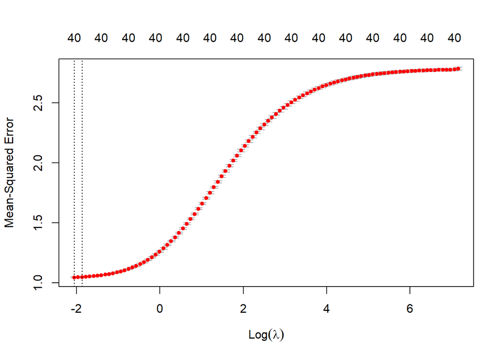

```r
#Format data and grid to prep for Ridge Regression
x <- model.matrix(scaled_sci~., data)[,-1]
y <- data$scaled_sci
y.test <-y[test_index]
grid <- 10^seq(10, -2, length = 100)

#Fit the Model
ridge.mod <- glmnet(x[train_index,], y[train_index], alpha = 0, lamda = grid, thresh = 1e-12)

set.seed(30)

#Use Cross validation to find best value of lambda
cv.out <- cv.glmnet(x[train_index,], y[train_index], alpha = 0)
plot(cv.out)
```

```r
bestlam <- cv.out$lambda.min
bestlam
```

```
## [1] 0.1280443
```

```r
#Fit predictions with best value of lambda
ridge.pred <- predict(ridge.mod, s = bestlam, newx = x[test_index, ])

#Calculate MSE
MSE.ridge <- mean((ridge.pred - y.test)^2)
MSE.ridge
```

```
## [1] 1.040158
```

```r
#Add MSE and Name to lists
MSE_All <- c(MSE_All, MSE.ridge)
MSE_Name <- c(MSE_Name, 'Ridge')
```

The ridge MSE is 1.040158, which is actually slightly higher than our forward selection model.

Next we will run Lasso

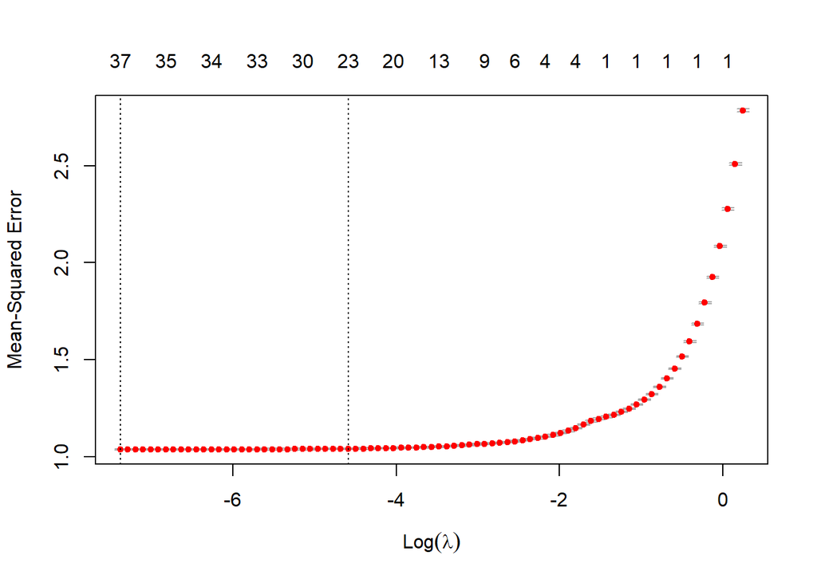

```r
#Build the model
lasso.mod <- glmnet(x[train_index, ], y[train_index], alpha =1, lamda = grid)
set.seed(52)

#Use cross validation to select best value of lamda
cv.out <- cv.glmnet(x[train_index, ], y[train_index], alpha = 1)
plot(cv.out)
```

```r
bestlam <- cv.out$lambda.min
bestlam
```

```
## [1] 0.0006226283
```

```r
#Fit predictions for test set using best value of lambda
lasso.pred <- predict(lasso.mod, s = bestlam, newx = x[test_index, ])

#Calculate MSE
MSE.lasso <- mean((lasso.pred - y.test)^2)

#Look at variables of interest
out <-  glmnet( x, y, alpha = 1, lamda = grid)
lasso.coef <- predict(out, type = 'coefficients', s = bestlam)[1:18,]
lasso.coef
```

```
##                 (Intercept)    ACS_TOT_POP_US_ABOVE1_ZC
##                 14.00597886                 -0.72640147
##             ACS_PCT_MALE_ZC     ACS_PCT_FOREIGN_BORN_ZC
##                  0.48361661                 -0.01993139
## ACS_PCT_HH_LIMIT_ENGLISH_ZC         ACS_PCT_OTH_LANG_ZC
##                  0.00000000                  0.11083013
##          ACS_PCT_SPANISH_ZC           ACS_MEDIAN_AGE_ZC
##                 -0.26432050                  0.52209215
##            ACS_PCT_ASIAN_ZC            ACS_PCT_BLACK_ZC
##                 -0.13961763                  0.21502896
##         ACS_PCT_HISPANIC_ZC        ACS_PCT_MULT_RACE_ZC
##                 -0.33494716                  0.23400914
##             ACS_PCT_NHPI_ZC       ACS_PCT_OTHER_RACE_ZC
##                 -0.26050925                  0.08621995
##            ACS_PCT_WHITE_ZC   ACS_PCT_HH_NO_COMP_DEV_ZC
##                 -0.87787452                 -0.15660727
##    ACS_PCT_HH_SMARTPHONE_ZC      ACS_PCT_HH_CELLULAR_ZC
##                 -0.01635046                  0.24556234
```

```r
MSE.lasso
```

```
## [1] 1.032842
```

```r
#Add MSE and Name to lists
MSE_All <- c(MSE_All, MSE.lasso)
MSE_Name <- c(MSE_Name, 'Lasso')
```

Next we will run Ridge Regression on only the variables selected with forward selection to see if we can decrease the MSE.

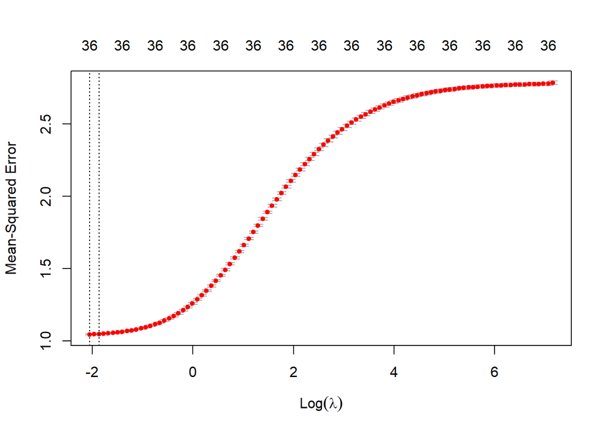

```r
#Format data and grid to prep for Ridge Regression
x <- model.matrix(scaled_sci~., fwd_select_data)[,-1]
y <- fwd_select_data$scaled_sci
y.test <-y[test_index]
grid <- 10^seq(10, -2, length = 100)

#Fit the Model
ridge.mod <- glmnet(x[train_index,], y[train_index], alpha = 0, lamda = grid, thresh = 1e-12)

set.seed(30)

#Use Cross validation to find best value of lambda
cv.out <- cv.glmnet(x[train_index,], y[train_index], alpha = 0)
plot(cv.out)
```

```r
bestlam <- cv.out$lambda.min
bestlam
```

```
## [1] 0.1280443
```

```r
#Fit predictions with best value of lambda
ridge.pred <- predict(ridge.mod, s = bestlam, newx = x[test_index, ])

#Calculate MSE
MSE.ridge_fwd <- mean((ridge.pred - y.test)^2)
MSE.ridge_fwd
```

```
## [1] 1.040132
```

```r
#Add MSE and Name to lists
MSE_All <- c(MSE_All, MSE.ridge)
MSE_Name <- c(MSE_Name, 'Ridge FWD')
```

Next we will run Lasso on the limited variable list.

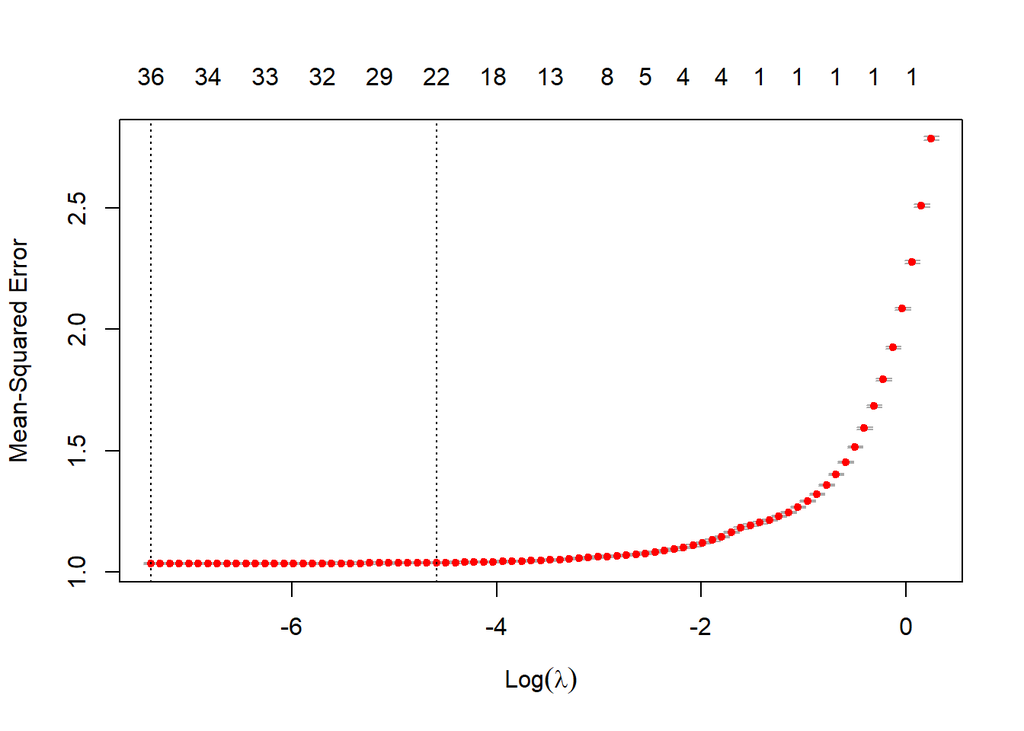

```r
#Build the model
lasso.mod <- glmnet(x[train_index, ], y[train_index], alpha =1, lamda = grid)
set.seed(52)

#Use cross validation to select best value of lambda
cv.out <- cv.glmnet(x[train_index, ], y[train_index], alpha = 1)
plot(cv.out)
```

```r
bestlam <- cv.out$lambda.min
bestlam
```

```
## [1] 0.0006226283
```

```r
#Fit predictions for test set using best value of lambda
lasso.pred <- predict(lasso.mod, s = bestlam, newx = x[test_index, ])

#Calculate MSE
MSE.lasso_fwd <- mean((lasso.pred - y.test)^2)

#Look at variables of interest
out <-  glmnet( x, y, alpha = 1, lamda = grid)
lasso.coef <- predict(out, type = 'coefficients', s = bestlam)[1:18,]
lasso.coef
```

```
##               (Intercept)  ACS_TOT_POP_US_ABOVE1_ZC           ACS_PCT_MALE_ZC
##               14.00626723               -0.72698901                0.48012487
##       ACS_PCT_OTH_LANG_ZC        ACS_PCT_SPANISH_ZC         ACS_MEDIAN_AGE_ZC
##                0.10314603               -0.27256552                0.51931510
##          ACS_PCT_ASIAN_ZC          ACS_PCT_BLACK_ZC       ACS_PCT_HISPANIC_ZC
##               -0.15319505                0.18788541               -0.32650716
##      ACS_PCT_MULT_RACE_ZC           ACS_PCT_NHPI_ZC     ACS_PCT_OTHER_RACE_ZC
##                0.21920559               -0.25790541                0.07196372
##          ACS_PCT_WHITE_ZC ACS_PCT_HH_NO_COMP_DEV_ZC    ACS_PCT_HH_CELLULAR_ZC
##               -0.85222635               -0.15784994                0.22989697
##       ACS_PCT_EMPLOYED_ZC         ACS_GINI_INDEX_ZC     ACS_PER_CAPITA_INC_ZC
##                0.20114824                0.15785816               -0.27918867
```

```r
MSE.lasso_fwd
```

```
## [1] 1.032839
```

```r
#Add MSE and Name to lists
MSE_All <- c(MSE_All, MSE.lasso_fwd)
MSE_Name <- c(MSE_Name, 'Lasso FWD')
```

The MSE is still larger than that from forward selection ( 1.032839 vs 1.032774)

It is interesting to note that multiple linear regression is out performing Ridge and Lasso. However, since we are using MSE as a model selection criterion, and we are selecting lambda with cross validation, variations in the specific test set would explain these differences especially since Lasso and Ridge also appear to be performing rather similar to multiple linear regression.

Next we will create a tree

```r
set.seed(77)
#Build and plot the tree
data_tree <- df_full[2:41] %>% filter(distance > 0)
train_tree <- data_tree[train_index,]
test_tree <- data_tree[test_index,]
tree <- tree( scaled_sci ~ ., data_tree, subset = train_index )
plot(tree)
summary(tree)
```

```
##
## Regression tree:
## tree(formula = scaled_sci ~ ., data = data_tree, subset = train_index)
## Variables actually used in tree construction:
## [1] "distance" "urbrur"
## Number of terminal nodes:  8
## Residual mean deviance:  0.7835 = 162000 / 206700
## Distribution of residuals:
##      Min.   1st Qu.    Median      Mean   3rd Qu.      Max.
## -10.59000  -0.55240  -0.03635   0.00000   0.52000   5.11300
```

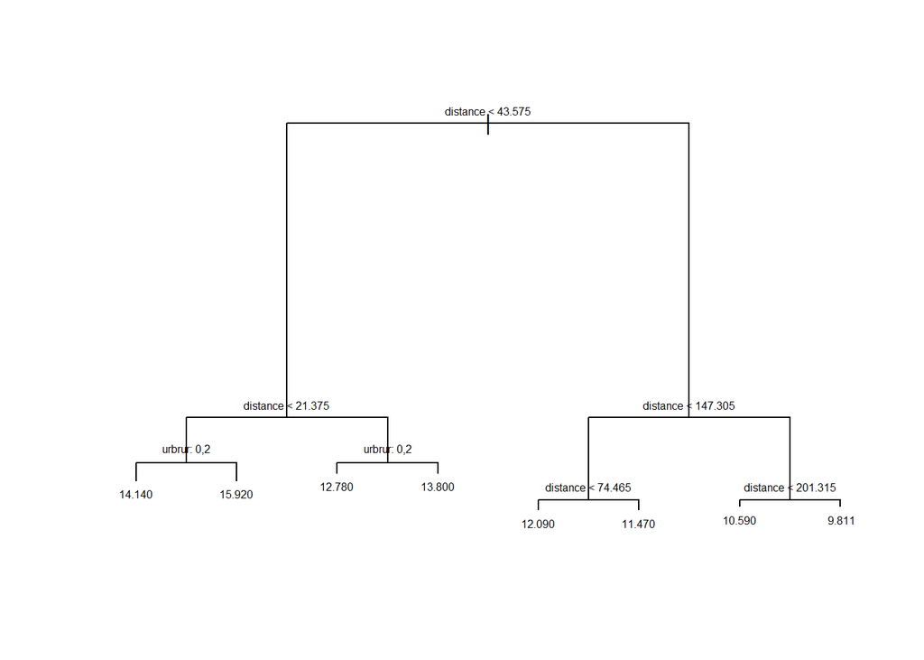

```r
text(tree, pretty = 0, cex = .5)
```

```r
#Make predictions and calculate MSE
tree.pred <- predict(tree, test_tree)
MSE.tree <- mean((tree.pred - test_tree$scaled_sci)^2)
MSE.tree
```

```
## [1] 0.782236
```

```r
#Add MSE and Name to lists
MSE_All <- c(MSE_All, MSE.tree)
MSE_Name <- c(MSE_Name, 'Full Tree')
```

The MSE of the full tree is 0.782236, the lowest MSE yet.

Let’s use cross validation to see if we should prune the tree

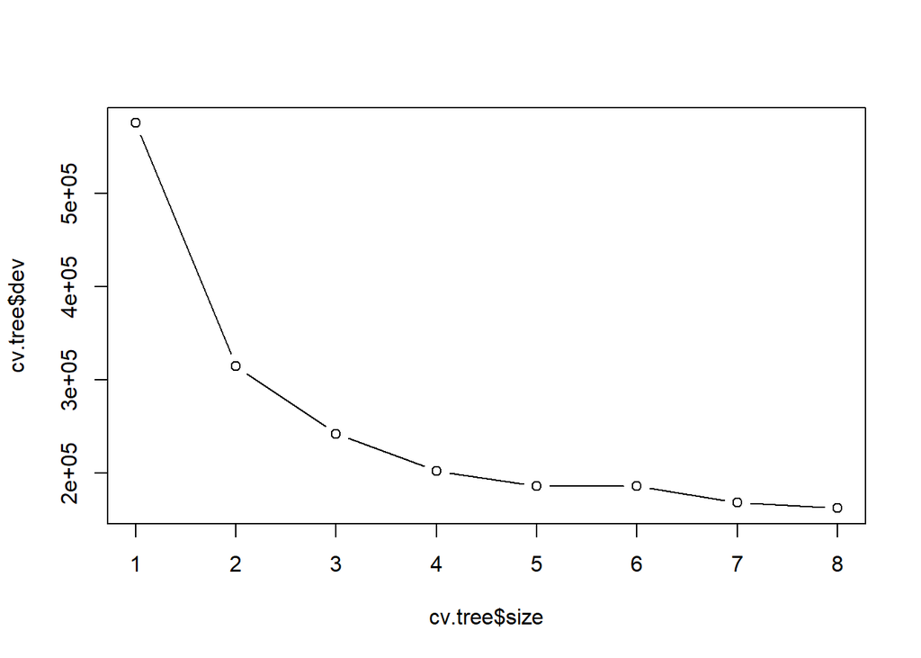

```r
#Run cross validation and plot to see which size is the best
cv.tree <- cv.tree(tree)
plot(cv.tree$size, cv.tree$dev, type = 'b')
```

The unpruned tree seems to minimize the MSE, so we will stick with it.

Although we have found the decision tree works bests, let’s look at a graph of all the MSEs of all of the models we tried.

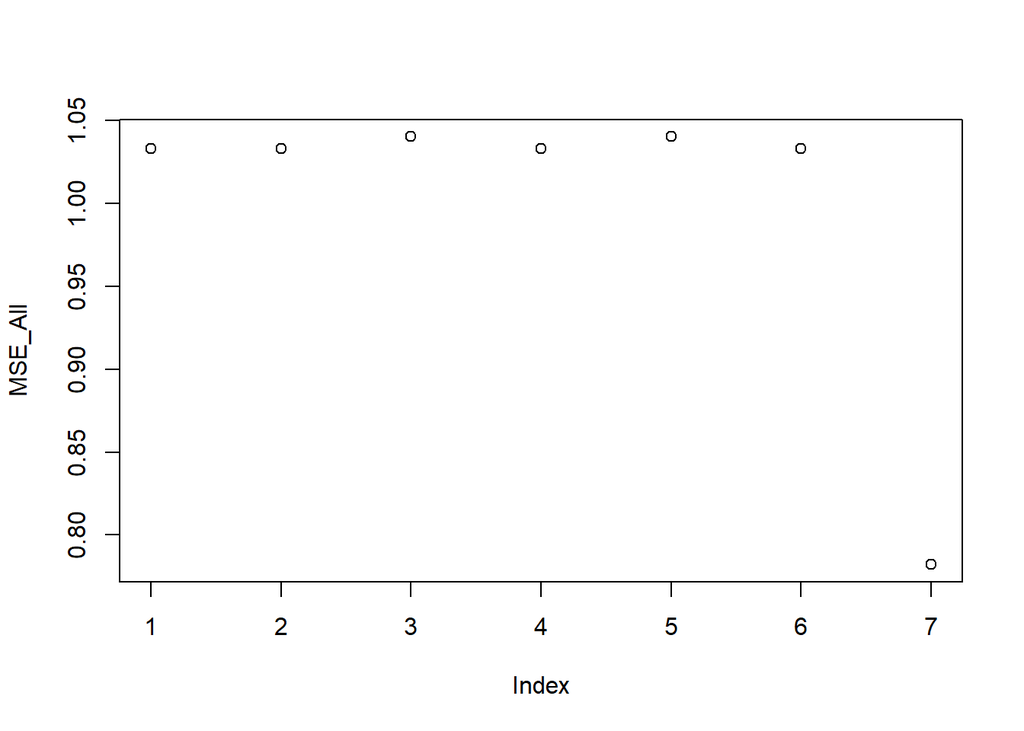

```r
plot(MSE_All)
```

```r
color <- c(rep('Red', 6), 'Green')
MSE_All
```

```
## [1] 1.032799 1.032774 1.040158 1.032842 1.040158 1.032839 0.782236
```

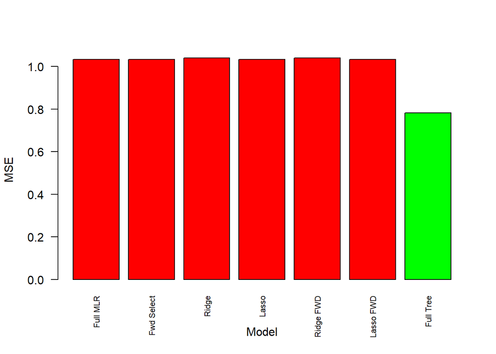

```r
barplot(MSE_All, names.arg = MSE_Name, las = 2, cex.names = .7, col = color, ylab = 'MSE', xlab = 'Model' )
```

We also need to investigate what causes variability in sci scores within one zip code.

```r
df_same_zip <- df_s %>% filter(distance == 0)
df_same_zip_merged <- merge(df_same_zip, df_sdoh_pa_selected, by.x = 'user_loc', by.y = 'ZIPCODE')
same_zip_data <- subset(df_same_zip_merged, select = -c(user_loc, fr_loc, distance, Count, county_fr, county_user, ur_fr, correlation))
same_zip_data <- na.omit(same_zip_data)

#Let's normalize the data
df_normalized_same <- same_zip_data
for (i in 3:39){
  df_normalized_same[,i]<-((same_zip_data[,i] - min(same_zip_data[,i]))/((max(same_zip_data[,i])-min(same_zip_data[,i]))))
}
same_zip_data <- df_normalized_same
cor(same_zip_data$scaled_sci, same_zip_data[3:39])
```

```
##      ACS_TOT_POP_US_ABOVE1_ZC ACS_PCT_MALE_ZC ACS_PCT_FOREIGN_BORN_ZC
## [1,]               -0.4815074      0.09985428              -0.4217747
##      ACS_PCT_HH_LIMIT_ENGLISH_ZC ACS_PCT_OTH_LANG_ZC ACS_PCT_SPANISH_ZC
## [1,]                  -0.2355292          -0.2814726         -0.2409882
##      ACS_MEDIAN_AGE_ZC ACS_PCT_ASIAN_ZC ACS_PCT_BLACK_ZC ACS_PCT_HISPANIC_ZC
## [1,]         0.2113993       -0.3467864       -0.2734733          -0.2751267
##      ACS_PCT_MULT_RACE_ZC ACS_PCT_NHPI_ZC ACS_PCT_OTHER_RACE_ZC
## [1,]           -0.2215813     -0.05235439            -0.2165323
##      ACS_PCT_WHITE_ZC ACS_PCT_HH_NO_COMP_DEV_ZC ACS_PCT_HH_SMARTPHONE_ZC
## [1,]        0.3767064                 0.3554596               -0.5022091
##      ACS_PCT_HH_CELLULAR_ZC ACS_PCT_HH_NO_INTERNET_ZC ACS_PCT_EMPLOYED_ZC
## [1,]             -0.5076469                 0.3729737         -0.02329072
##      ACS_GINI_INDEX_ZC ACS_PER_CAPITA_INC_ZC ACS_PCT_HH_FOOD_STMP_BLW_POV_ZC
## [1,]        -0.2126747            -0.3397705                      0.07554356
##      ACS_PCT_COLLEGE_ASSOCIATE_DGR_ZC ACS_PCT_BACHELOR_DGR_ZC
## [1,]                     -0.009267912               -0.473137
##      ACS_PCT_1UP_PERS_1ROOM_ZC ACS_PCT_DIF_STATE_ZC ACS_PCT_HH_ALONE_ABOVE65_ZC
## [1,]              -0.006306779           -0.2057416                  0.06256347
##      ACS_PCT_IN_COUNTY_MOVE_ZC ACS_PCT_IN_STATE_MOVE_ZC
## [1,]                -0.2006969               -0.1135198
##      ACS_PCT_COMMT_60MINUP_ZC ACS_PCT_DRIVE_2WORK_ZC ACS_PCT_HU_NO_VEH_ZC
## [1,]               0.05277464              0.2557112           -0.1741606
##      ACS_PCT_PUBL_TRANSIT_ZC ACS_PCT_WALK_2WORK_ZC ACS_PCT_WORK_NO_CAR_ZC
## [1,]              -0.3072209           -0.09675313             -0.1078437
##      ACS_PCT_UNINSURED_ZC CEN_POPDENSITY_ZC
## [1,]           0.09673839        -0.2989467
```

From the below plot, we can see that it might be of worth to take the log of sci.

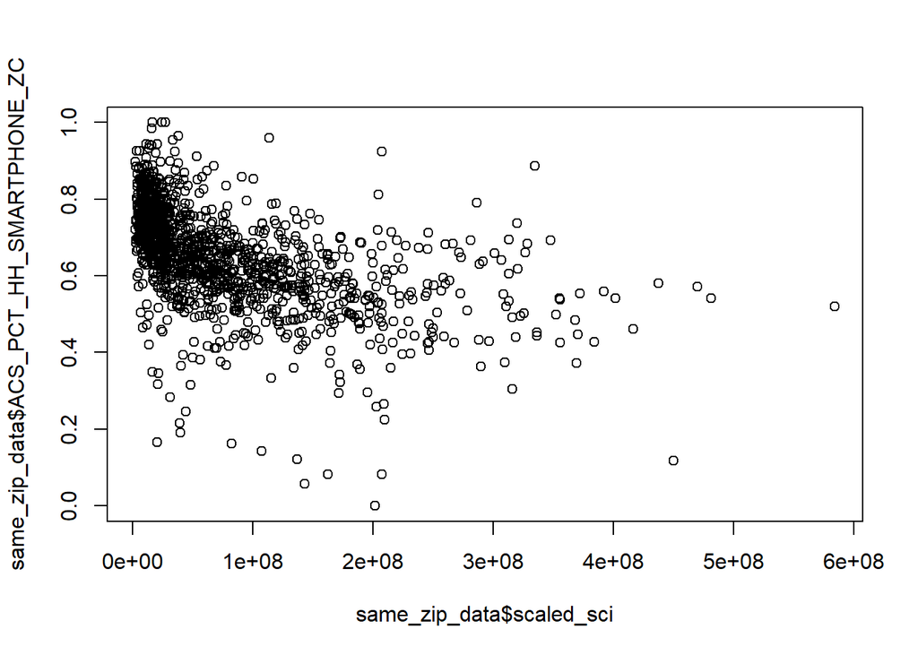

```r
plot(same_zip_data$scaled_sci, same_zip_data$ACS_PCT_HH_SMARTPHONE_ZC)
```

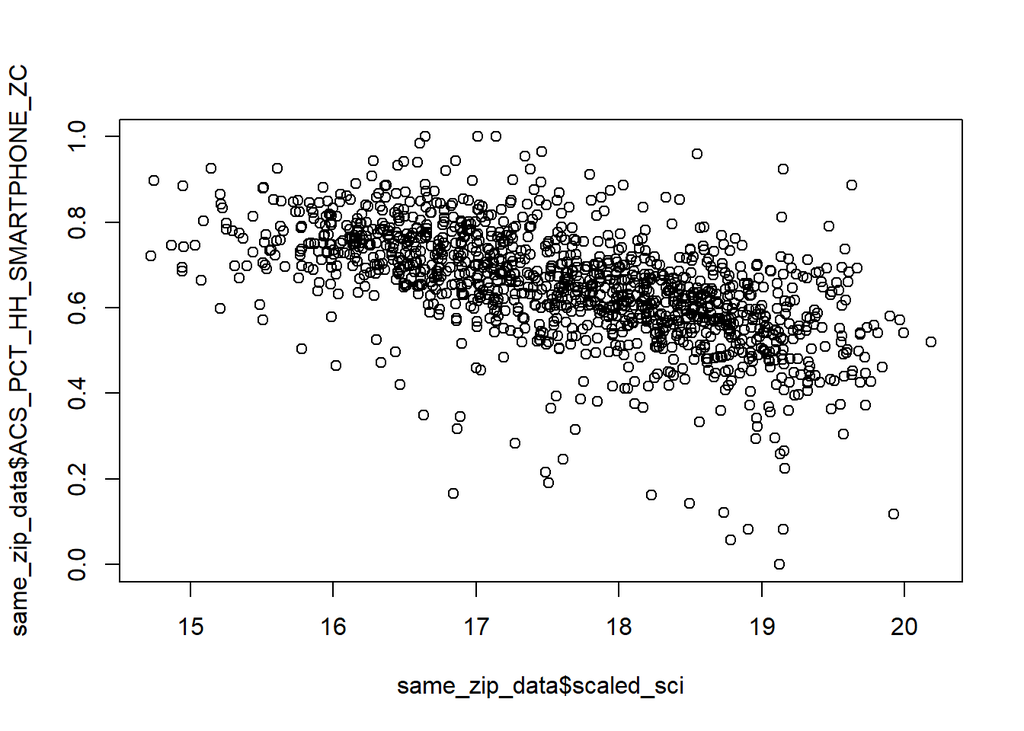

```r
same_zip_data$scaled_sci <- log(same_zip_data$scaled_sci)

plot(same_zip_data$scaled_sci, same_zip_data$ACS_PCT_HH_SMARTPHONE_ZC)
```

```r
cor(same_zip_data$scaled_sci, same_zip_data[3:39])
```

```
##      ACS_TOT_POP_US_ABOVE1_ZC ACS_PCT_MALE_ZC ACS_PCT_FOREIGN_BORN_ZC
## [1,]               -0.6908326       0.1404199               -0.623043
##      ACS_PCT_HH_LIMIT_ENGLISH_ZC ACS_PCT_OTH_LANG_ZC ACS_PCT_SPANISH_ZC
## [1,]                   -0.371412          -0.4350437         -0.3441229
##      ACS_MEDIAN_AGE_ZC ACS_PCT_ASIAN_ZC ACS_PCT_BLACK_ZC ACS_PCT_HISPANIC_ZC
## [1,]         0.3305384       -0.5495798       -0.4188058          -0.3799953
##      ACS_PCT_MULT_RACE_ZC ACS_PCT_NHPI_ZC ACS_PCT_OTHER_RACE_ZC
## [1,]           -0.2888827     -0.05083669            -0.3156851
##      ACS_PCT_WHITE_ZC ACS_PCT_HH_NO_COMP_DEV_ZC ACS_PCT_HH_SMARTPHONE_ZC
## [1,]        0.5690195                 0.4151915               -0.5744944
##      ACS_PCT_HH_CELLULAR_ZC ACS_PCT_HH_NO_INTERNET_ZC ACS_PCT_EMPLOYED_ZC
## [1,]             -0.5620339                 0.4233855          0.04340216
##      ACS_GINI_INDEX_ZC ACS_PER_CAPITA_INC_ZC ACS_PCT_HH_FOOD_STMP_BLW_POV_ZC
## [1,]         -0.287431            -0.3979278                      0.03785053
##      ACS_PCT_COLLEGE_ASSOCIATE_DGR_ZC ACS_PCT_BACHELOR_DGR_ZC
## [1,]                       0.06384707              -0.5750797
##      ACS_PCT_1UP_PERS_1ROOM_ZC ACS_PCT_DIF_STATE_ZC ACS_PCT_HH_ALONE_ABOVE65_ZC
## [1,]               -0.05413078           -0.3156482                  0.08466493
##      ACS_PCT_IN_COUNTY_MOVE_ZC ACS_PCT_IN_STATE_MOVE_ZC
## [1,]                -0.2593962               -0.1450166
##      ACS_PCT_COMMT_60MINUP_ZC ACS_PCT_DRIVE_2WORK_ZC ACS_PCT_HU_NO_VEH_ZC
## [1,]              -0.01220833              0.4505855            -0.275464
##      ACS_PCT_PUBL_TRANSIT_ZC ACS_PCT_WALK_2WORK_ZC ACS_PCT_WORK_NO_CAR_ZC
## [1,]              -0.5120972            -0.1892419             -0.2016225
##      ACS_PCT_UNINSURED_ZC CEN_POPDENSITY_ZC
## [1,]            0.1037946        -0.5155167
```

Most of the correlations have increased, which should help us with our model.

```r
set.seed(18)

#Create a training and test set with an 80/20 split.
test_index_same <- sample(1:nrow(same_zip_data), nrow(same_zip_data)/5)
allnums<- (1:nrow(same_zip_data))
train_index_same<- allnums[-test_index_same]
train_same <- same_zip_data[train_index_same,]
test_same <- same_zip_data[test_index_same,]
```

Now it is time to start building models. Let’s start by running multiple linear regression with all of the predictors. Since we are using MSE as a way to compare models, we will store all of the MSEs in one MSE list as we go.

```r
lm.fit_same <- lm(scaled_sci~., data = train_same)
predict <- predict.lm(lm.fit_same, newdata= test_same)

#Calculate MSE for this model and add to list
MSE.Full.MultiLin_same <- mean((test_same$scaled_sci - predict)^2)
MSE.Full.MultiLin_same
```

```
## [1] 0.2786184
```

```r
#Create empty MSE vector and empty vector names for the MSE
MSE_All_Same <- c(MSE.Full.MultiLin_same)
MSE_Name_Same <- c('Full MLR')
summary(lm.fit_same)
```

```
##
## Call:
## lm(formula = scaled_sci ~ ., data = train_same)
##
## Residuals:
##      Min       1Q   Median       3Q      Max
## -2.62124 -0.32164  0.01059  0.29202  2.31648
##
## Coefficients:
##                                    Estimate Std. Error t value Pr(>|t|)
## (Intercept)                       29.933703   6.606600   4.531 6.60e-06 ***
## ur_user                           -0.256482   0.021291 -12.047  < 2e-16 ***
## ACS_TOT_POP_US_ABOVE1_ZC          -1.996856   0.133963 -14.906  < 2e-16 ***
## ACS_PCT_MALE_ZC                    0.582725   0.253738   2.297 0.021855 *
## ACS_PCT_FOREIGN_BORN_ZC           -0.103743   0.350246  -0.296 0.767141
## ACS_PCT_HH_LIMIT_ENGLISH_ZC       -0.268965   0.382154  -0.704 0.481717
## ACS_PCT_OTH_LANG_ZC               -0.473504   0.195490  -2.422 0.015611 *
## ACS_PCT_SPANISH_ZC                 1.760467   0.656339   2.682 0.007436 **
## ACS_MEDIAN_AGE_ZC                 -0.136846   0.247358  -0.553 0.580231
## ACS_PCT_ASIAN_ZC                  -4.831719   2.333998  -2.070 0.038701 *
## ACS_PCT_BLACK_ZC                 -11.190718   6.257865  -1.788 0.074043 .
## ACS_PCT_HISPANIC_ZC               -3.570332   0.630316  -5.664 1.94e-08 ***
## ACS_PCT_MULT_RACE_ZC              -4.414508   2.927273  -1.508 0.131862
## ACS_PCT_NHPI_ZC                   -1.058106   0.737939  -1.434 0.151931
## ACS_PCT_OTHER_RACE_ZC             -3.303363   2.359478  -1.400 0.161819
## ACS_PCT_WHITE_ZC                 -10.921320   6.516215  -1.676 0.094054 .
## ACS_PCT_HH_NO_COMP_DEV_ZC          0.531345   0.332082   1.600 0.109913
## ACS_PCT_HH_SMARTPHONE_ZC          -0.182431   0.324615  -0.562 0.574251
## ACS_PCT_HH_CELLULAR_ZC            -0.913113   0.332774  -2.744 0.006182 **
## ACS_PCT_HH_NO_INTERNET_ZC          0.142495   0.317765   0.448 0.653943
## ACS_PCT_EMPLOYED_ZC               -0.293427   0.146462  -2.003 0.045407 *
## ACS_GINI_INDEX_ZC                  0.276066   0.233172   1.184 0.236718
## ACS_PER_CAPITA_INC_ZC             -0.534368   0.358629  -1.490 0.136539
## ACS_PCT_HH_FOOD_STMP_BLW_POV_ZC    0.683777   0.230515   2.966 0.003087 **
## ACS_PCT_COLLEGE_ASSOCIATE_DGR_ZC  -0.193390   0.171750  -1.126 0.260442
## ACS_PCT_BACHELOR_DGR_ZC           -0.951077   0.197320  -4.820 1.66e-06 ***
## ACS_PCT_1UP_PERS_1ROOM_ZC         -0.257765   0.181562  -1.420 0.156012
## ACS_PCT_DIF_STATE_ZC              -0.289786   0.183216  -1.582 0.114050
## ACS_PCT_HH_ALONE_ABOVE65_ZC       -0.002215   0.253202  -0.009 0.993021
## ACS_PCT_IN_COUNTY_MOVE_ZC         -0.217400   0.191322  -1.136 0.256107
## ACS_PCT_IN_STATE_MOVE_ZC          -0.325681   0.197406  -1.650 0.099305 .
## ACS_PCT_COMMT_60MINUP_ZC           0.259571   0.142584   1.820 0.068992 .
## ACS_PCT_DRIVE_2WORK_ZC             0.158483   0.944036   0.168 0.866714
## ACS_PCT_HU_NO_VEH_ZC              -1.163367   0.331814  -3.506 0.000475 ***
## ACS_PCT_PUBL_TRANSIT_ZC           -0.590166   0.555394  -1.063 0.288222
## ACS_PCT_WALK_2WORK_ZC              0.016220   1.004662   0.016 0.987122
## ACS_PCT_WORK_NO_CAR_ZC             0.691881   0.337446   2.050 0.040597 *
## ACS_PCT_UNINSURED_ZC              -0.495656   0.246937  -2.007 0.045002 *
## CEN_POPDENSITY_ZC                  0.273265   0.366662   0.745 0.456283
## ---
## Signif. codes:  0 '***' 0.001 '**' 0.01 '*' 0.05 '.' 0.1 ' ' 1
##
## Residual standard error: 0.5031 on 977 degrees of freedom
## Multiple R-squared:  0.8006, Adjusted R-squared:  0.7928
## F-statistic: 103.2 on 38 and 977 DF,  p-value: < 2.2e-16
```

Now we will try forward selection to find the best multiple linear regression model.

```r
#Fit Models
regfit.fwd_same <- regsubsets (scaled_sci ~ ., data = train_same, nvmax = 37 , method = "forward")
test.mat_same <- model.matrix(scaled_sci ~., data = test_same)
regfit.fwd_same
```

```
## Subset selection object
## Call: regsubsets.formula(scaled_sci ~ ., data = train_same, nvmax = 37,
##     method = "forward")
## 38 Variables  (and intercept)
##                                  Forced in Forced out
## ur_user                              FALSE      FALSE
## ACS_TOT_POP_US_ABOVE1_ZC             FALSE      FALSE
## ACS_PCT_MALE_ZC                      FALSE      FALSE
## ACS_PCT_FOREIGN_BORN_ZC              FALSE      FALSE
## ACS_PCT_HH_LIMIT_ENGLISH_ZC          FALSE      FALSE
## ACS_PCT_OTH_LANG_ZC                  FALSE      FALSE
## ACS_PCT_SPANISH_ZC                   FALSE      FALSE
## ACS_MEDIAN_AGE_ZC                    FALSE      FALSE
## ACS_PCT_ASIAN_ZC                     FALSE      FALSE
## ACS_PCT_BLACK_ZC                     FALSE      FALSE
## ACS_PCT_HISPANIC_ZC                  FALSE      FALSE
## ACS_PCT_MULT_RACE_ZC                 FALSE      FALSE
## ACS_PCT_NHPI_ZC                      FALSE      FALSE
## ACS_PCT_OTHER_RACE_ZC                FALSE      FALSE
## ACS_PCT_WHITE_ZC                     FALSE      FALSE
## ACS_PCT_HH_NO_COMP_DEV_ZC            FALSE      FALSE
## ACS_PCT_HH_SMARTPHONE_ZC             FALSE      FALSE
## ACS_PCT_HH_CELLULAR_ZC               FALSE      FALSE
## ACS_PCT_HH_NO_INTERNET_ZC            FALSE      FALSE
## ACS_PCT_EMPLOYED_ZC                  FALSE      FALSE
## ACS_GINI_INDEX_ZC                    FALSE      FALSE
## ACS_PER_CAPITA_INC_ZC                FALSE      FALSE
## ACS_PCT_HH_FOOD_STMP_BLW_POV_ZC      FALSE      FALSE
## ACS_PCT_COLLEGE_ASSOCIATE_DGR_ZC     FALSE      FALSE
## ACS_PCT_BACHELOR_DGR_ZC              FALSE      FALSE
## ACS_PCT_1UP_PERS_1ROOM_ZC            FALSE      FALSE
## ACS_PCT_DIF_STATE_ZC                 FALSE      FALSE
## ACS_PCT_HH_ALONE_ABOVE65_ZC          FALSE      FALSE
## ACS_PCT_IN_COUNTY_MOVE_ZC            FALSE      FALSE
## ACS_PCT_IN_STATE_MOVE_ZC             FALSE      FALSE
## ACS_PCT_COMMT_60MINUP_ZC             FALSE      FALSE
## ACS_PCT_DRIVE_2WORK_ZC               FALSE      FALSE
## ACS_PCT_HU_NO_VEH_ZC                 FALSE      FALSE
## ACS_PCT_PUBL_TRANSIT_ZC              FALSE      FALSE
## ACS_PCT_WALK_2WORK_ZC                FALSE      FALSE
## ACS_PCT_WORK_NO_CAR_ZC               FALSE      FALSE
## ACS_PCT_UNINSURED_ZC                 FALSE      FALSE
## CEN_POPDENSITY_ZC                    FALSE      FALSE
## 1 subsets of each size up to 37
## Selection Algorithm: forward
```

```r
#Calculate MSE for each model size
val.errors_same <- rep (NA , 37)
for (i in 1:37) {
  coefi <- coef ( regfit.fwd_same , id = i)
  pred <- test.mat_same [, names ( coefi )] %*% coefi
  val.errors_same [ i] <- mean (( test_same$scaled_sci - pred ) ^2)
}
val.errors_same
```

```
##  [1] 0.6144223 0.4249239 0.3735975 0.3426139 0.3378458 0.3155291 0.3042564
##  [8] 0.2904484 0.2820243 0.2835640 0.2963909 0.2840143 0.2852543 0.2820444
## [15] 0.2797501 0.2790181 0.2742762 0.2752693 0.2681383 0.2684652 0.2712590
## [22] 0.2732288 0.2732010 0.2693403 0.2723313 0.2733649 0.2745245 0.2738679
## [29] 0.2725728 0.2763377 0.2766839 0.2764630 0.2759158 0.2782955 0.2788423
## [36] 0.2785880 0.2786211
```

```r
#Find the model with the smallest MSE
which.min(val.errors_same)
```

```
## [1] 19
```

```r
MSE.Forward_same <- val.errors_same[which.min(val.errors_same)]
MSE.Forward_same
```

```
## [1] 0.2681383
```

```r
#Add MSE and Name to lists
MSE_All_Same <- c(MSE_All_Same, MSE.Forward_same)
MSE_Name_Same <- c(MSE_Name_Same, 'Fwd Select')
```

19 predictors minimize our MSE to 0.2681383

Let’s look more closely at this model

```r
fwd_same_vars<- which(summary(regfit.fwd_same, which.min(val.errors_same))$which[which.min(val.errors_same),])
fwd_select_data_same <- subset(same_zip_data, select = fwd_same_vars)
fwd_train_same <- fwd_select_data_same[train_index_same,]
fwd_test_same <- fwd_select_data_same[test_index_same,]
fwd.fit_same <- lm(scaled_sci~. , data = fwd_train_same)
predict <- predict.lm(fwd.fit_same, newdata= fwd_test_same)
summary(fwd.fit_same)
```

```
##
## Call:
## lm(formula = scaled_sci ~ ., data = fwd_train_same)
##
## Residuals:
##      Min       1Q   Median       3Q      Max
## -2.64249 -0.32352 -0.00019  0.29686  2.29671
##
## Coefficients:
##                                 Estimate Std. Error t value Pr(>|t|)
## (Intercept)                     20.03309    0.66220  30.252  < 2e-16 ***
## ur_user                         -0.26751    0.02038 -13.128  < 2e-16 ***
## ACS_TOT_POP_US_ABOVE1_ZC        -1.95687    0.12780 -15.312  < 2e-16 ***
## ACS_PCT_MALE_ZC                  0.58836    0.23766   2.476 0.013464 *
## ACS_PCT_FOREIGN_BORN_ZC         -0.28069    0.32160  -0.873 0.382989
## ACS_PCT_OTH_LANG_ZC             -0.48662    0.19119  -2.545 0.011069 *
## ACS_PCT_SPANISH_ZC               1.43922    0.61651   2.334 0.019770 *
## ACS_PCT_ASIAN_ZC                -1.37769    0.37944  -3.631 0.000297 ***
## ACS_PCT_BLACK_ZC                -2.00276    0.59619  -3.359 0.000811 ***
## ACS_PCT_HISPANIC_ZC             -3.13385    0.60671  -5.165 2.90e-07 ***
## ACS_PCT_WHITE_ZC                -1.20075    0.59219  -2.028 0.042861 *
## ACS_PCT_HH_SMARTPHONE_ZC        -0.46720    0.26360  -1.772 0.076642 .
## ACS_PCT_HH_CELLULAR_ZC          -0.78697    0.30386  -2.590 0.009741 **
## ACS_PCT_HH_NO_INTERNET_ZC        0.52786    0.20659   2.555 0.010764 *
## ACS_PCT_EMPLOYED_ZC             -0.25402    0.14233  -1.785 0.074623 .
## ACS_PCT_HH_FOOD_STMP_BLW_POV_ZC  0.79217    0.20128   3.936 8.87e-05 ***
## ACS_PCT_BACHELOR_DGR_ZC         -1.01447    0.16629  -6.101 1.51e-09 ***
## ACS_PCT_DIF_STATE_ZC            -0.30588    0.17278  -1.770 0.076976 .
## ACS_PCT_DRIVE_2WORK_ZC           0.29636    0.22650   1.308 0.191031
## ACS_PCT_HU_NO_VEH_ZC            -0.87308    0.22458  -3.888 0.000108 ***
## ---
## Signif. codes:  0 '***' 0.001 '**' 0.01 '*' 0.05 '.' 0.1 ' ' 1
##
## Residual standard error: 0.5044 on 996 degrees of freedom
## Multiple R-squared:  0.7957, Adjusted R-squared:  0.7918
## F-statistic: 204.1 on 19 and 996 DF,  p-value: < 2.2e-16
```

With this model we have a multiple r squared of .7957 and an adjusted R-squared of .7918, meaning we are able to explain about 79% of the variability in log(scaled_sci) with the 19 above predictors. Some of the variables that contribute to the model the most include: ur_user, ACS_TOT_POP_US_ABOVE1_ZC, ACS_PCT_HISPANIC_ZC and ACS_PCT_BACHELOR_DGR_ZC.

Next we will run Ridge Regression on the same zipcodes to see if we can decrease the MSE

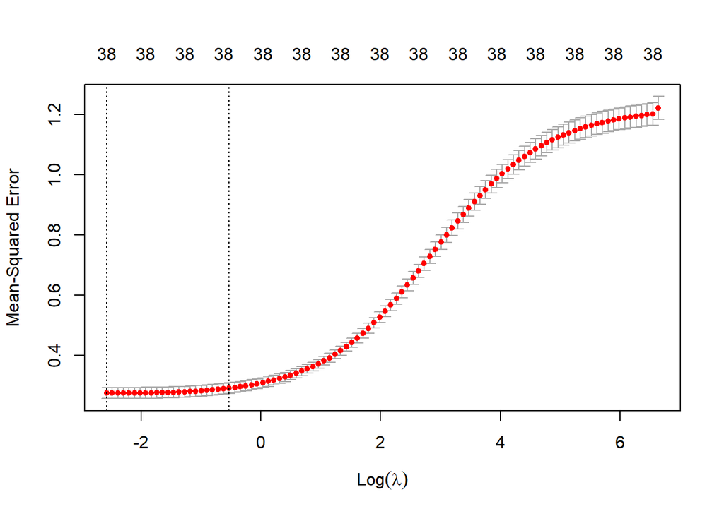

```r
#Format data and grid to prep for Ridge Regression
x <- model.matrix(scaled_sci~., same_zip_data)[,-1]
y <- same_zip_data$scaled_sci
y.test <-y[test_index_same]
grid <- 10^seq(10, -2, length = 100)

#Fit the Model
ridge.mod_same <- glmnet(x[train_index_same,], y[train_index_same], alpha = 0, lamda = grid, thresh = 1e-12)

set.seed(15)

#Use Cross validation to find best value of lambda
cv.out_same <- cv.glmnet(x[train_index_same,], y[train_index_same], alpha = 0)
plot(cv.out_same)
```

```r
bestlam_same <- cv.out_same$lambda.min
bestlam_same
```

```
## [1] 0.07625796
```

```r
#Fit predictions with best value of lambda
ridge.pred_same <- predict(ridge.mod_same, s = bestlam_same, newx = x[test_index_same, ])

#Calculate MSE
MSE.ridge_same <- mean((ridge.pred_same - y.test)^2)
MSE.ridge_same
```

```
## [1] 0.2706224
```

```r
#Add MSE and Name to lists
MSE_All_Same <- c(MSE_All_Same, MSE.ridge_same)
MSE_Name_Same <- c(MSE_Name_Same, 'Ridge')
```

Next we will run Lasso

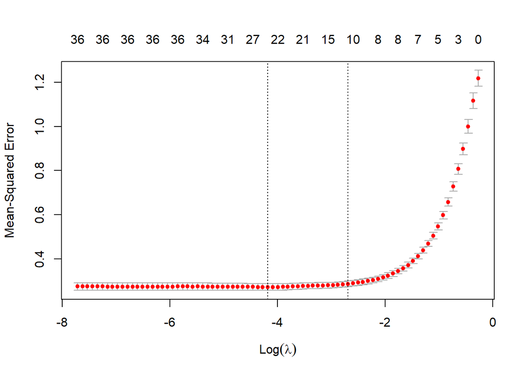

```r
#Build the model
lasso.mod_same <- glmnet(x[train_index_same, ], y[train_index_same], alpha =1, lamda = grid)
set.seed(117)

#Use cross validation to select best value of lamda
cv.out_same <- cv.glmnet(x[train_index_same, ], y[train_index_same], alpha = 1)
plot(cv.out_same)
```

```r
bestlam_same <- cv.out_same$lambda.min

#Fit predictions for test set using best value of lambda
lasso.pred_same <- predict(lasso.mod_same, s = bestlam_same, newx = x[test_index_same, ])

#Calculate MSE
MSE.lasso_same <- mean((lasso.pred_same - y.test)^2)

#Look at variables of interest
out <-  glmnet( x, y, alpha = 1, lamda = grid)
lasso.coef <- predict(out, type = 'coefficients', s = bestlam)[1:18,]
lasso.coef
```

```
##                 (Intercept)                     ur_user
##                 19.74410927                 -0.25577161
##    ACS_TOT_POP_US_ABOVE1_ZC             ACS_PCT_MALE_ZC
##                 -2.01138655                  0.57400873
##     ACS_PCT_FOREIGN_BORN_ZC ACS_PCT_HH_LIMIT_ENGLISH_ZC
##                 -0.08158148                 -0.19307488
##         ACS_PCT_OTH_LANG_ZC          ACS_PCT_SPANISH_ZC
##                 -0.56054326                  0.68449089
##           ACS_MEDIAN_AGE_ZC            ACS_PCT_ASIAN_ZC
##                 -0.13566400                 -0.94557979
##            ACS_PCT_BLACK_ZC         ACS_PCT_HISPANIC_ZC
##                 -0.80866841                 -2.45498356
##        ACS_PCT_MULT_RACE_ZC             ACS_PCT_NHPI_ZC
##                  0.64012936                 -0.33543507
##       ACS_PCT_OTHER_RACE_ZC            ACS_PCT_WHITE_ZC
##                  0.38441786                  0.00000000
##   ACS_PCT_HH_NO_COMP_DEV_ZC    ACS_PCT_HH_SMARTPHONE_ZC
##                  0.10321163                 -0.32441411
```

```r
MSE.lasso_same
```

```
## [1] 0.2641828
```

```r
#Add MSE and Name to lists
MSE_All_Same <- c(MSE_All_Same, MSE.lasso_same)
MSE_Name_Same <- c(MSE_Name_Same, 'Lasso')
```

Next we will run Ridge Regression but only using the variables selected with forward selection.

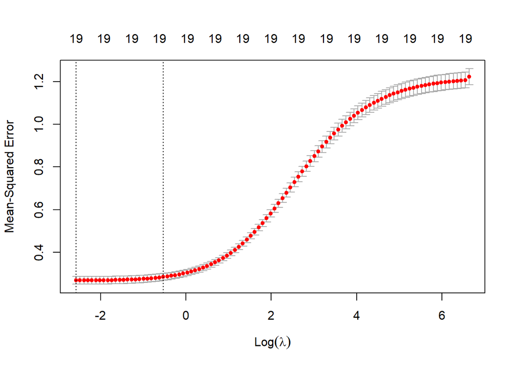

```r
#Format data and grid to prep for Ridge Regression
x <- model.matrix(scaled_sci~., fwd_select_data_same)[,-1]
y <- fwd_select_data_same$scaled_sci
y.test <-y[test_index_same]
grid <- 10^seq(10, -2, length = 100)

#Fit the Model
ridge.mod_same <- glmnet(x[train_index_same,], y[train_index_same], alpha = 0, lamda = grid, thresh = 1e-12)

set.seed(15)

#Use Cross validation to find best value of lambda
cv.out_same <- cv.glmnet(x[train_index_same,], y[train_index_same], alpha = 0)
plot(cv.out_same)
```

```r
bestlam_same_fwd <- cv.out_same$lambda.min
bestlam_same_fwd
```

```
## [1] 0.07625796
```

```r
#Fit predictions with best value of lambda
ridge.pred_same <- predict(ridge.mod_same, s = bestlam_same_fwd, newx = x[test_index_same, ])

#Calculate MSE
MSE.ridge_same_fwd <- mean((ridge.pred_same - y.test)^2)
MSE.ridge_same_fwd
```

```
## [1] 0.2655286
```

```r
#Add MSE and Name to lists
MSE_All_Same <- c(MSE_All_Same, MSE.ridge_same_fwd)
MSE_Name_Same <- c(MSE_Name_Same, 'Ridge FWD')
```

Next we will run Lasso

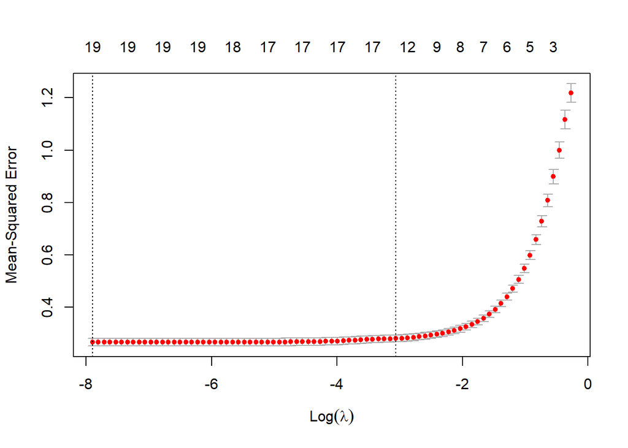

```r
#Build the model
lasso.mod_same <- glmnet(x[train_index_same, ], y[train_index_same], alpha =1, lamda = grid)
set.seed(117)

#Use cross validation to select best value of lambda
cv.out_same <- cv.glmnet(x[train_index_same, ], y[train_index_same], alpha = 1)
plot(cv.out_same)
```

```r
bestlam_same <- cv.out_same$lambda.min

#Fit predictions for test set using best value of lambda
lasso.pred_same <- predict(lasso.mod_same, s = bestlam_same, newx = x[test_index_same, ])

#Calculate MSE
MSE.lasso_same_fwd <- mean((lasso.pred_same - y.test)^2)

#Look at variables of interest
out <-  glmnet( x, y, alpha = 1, lamda = grid)
lasso.coef <- predict(out, type = 'coefficients', s = bestlam)[1:18,]
lasso.coef
```

```
##                     (Intercept)                         ur_user
##                      20.2748827                      -0.2603506
##        ACS_TOT_POP_US_ABOVE1_ZC                 ACS_PCT_MALE_ZC
##                      -2.0061511                       0.5593201
##         ACS_PCT_FOREIGN_BORN_ZC             ACS_PCT_OTH_LANG_ZC
##                      -0.2599682                      -0.5252476
##              ACS_PCT_SPANISH_ZC                ACS_PCT_ASIAN_ZC
##                       0.4085703                      -1.2266995
##                ACS_PCT_BLACK_ZC             ACS_PCT_HISPANIC_ZC
##                      -1.8308164                      -2.0425120
##                ACS_PCT_WHITE_ZC        ACS_PCT_HH_SMARTPHONE_ZC
##                      -0.9248448                      -0.3965789
##          ACS_PCT_HH_CELLULAR_ZC       ACS_PCT_HH_NO_INTERNET_ZC
##                      -0.9593802                       0.4269770
##             ACS_PCT_EMPLOYED_ZC ACS_PCT_HH_FOOD_STMP_BLW_POV_ZC
##                      -0.2084653                       0.7350192
##         ACS_PCT_BACHELOR_DGR_ZC            ACS_PCT_DIF_STATE_ZC
##                      -1.1117039                      -0.5123057
```

```r
MSE.lasso_same_fwd
```

```
## [1] 0.2676027
```

```r
#Add MSE and Name to lists
MSE_All_Same <- c(MSE_All_Same, MSE.lasso_same_fwd)
MSE_Name_Same <- c(MSE_Name_Same, 'Lasso Fwd')
```

Next we will create a tree

```r
set.seed(77)
#Build and plot the tree
tree_same <- tree( scaled_sci ~ ., same_zip_data, subset = train_index_same )
plot(tree_same)
summary(tree_same)
```

```
##
## Regression tree:
## tree(formula = scaled_sci ~ ., data = same_zip_data, subset = train_index_same)
## Variables actually used in tree construction:
## [1] "ACS_PCT_FOREIGN_BORN_ZC"  "ur_user"
## [3] "ACS_TOT_POP_US_ABOVE1_ZC" "CEN_POPDENSITY_ZC"
## [5] "ACS_PCT_BACHELOR_DGR_ZC"
## Number of terminal nodes:  10
## Residual mean deviance:  0.2949 = 296.6 / 1006
## Distribution of residuals:
##      Min.   1st Qu.    Median      Mean   3rd Qu.      Max.
## -3.272000 -0.351000 -0.007297  0.000000  0.341700  2.094000
```

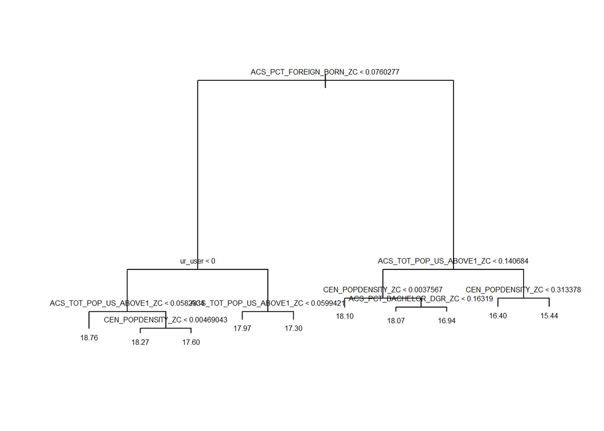

```r
text(tree_same, pretty = 0, cex = .5)
```

```r
#Make predictions and calculate MSE
tree.pred_same <- predict(tree_same, test_same)
MSE.tree_same <- mean((tree.pred_same - test_same$scaled_sci)^2)
MSE.tree_same
```

```
## [1] 0.3282718
```

```r
#Add MSE and Name to lists
MSE_All_Same <- c(MSE_All_Same, MSE.tree_same)
MSE_Name_Same <- c(MSE_Name_Same, 'Full Tree')
```

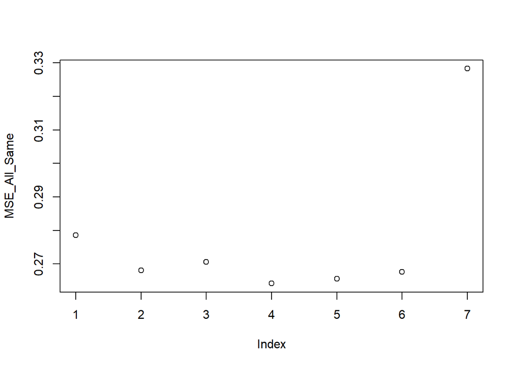

```r
plot(MSE_All_Same)
```

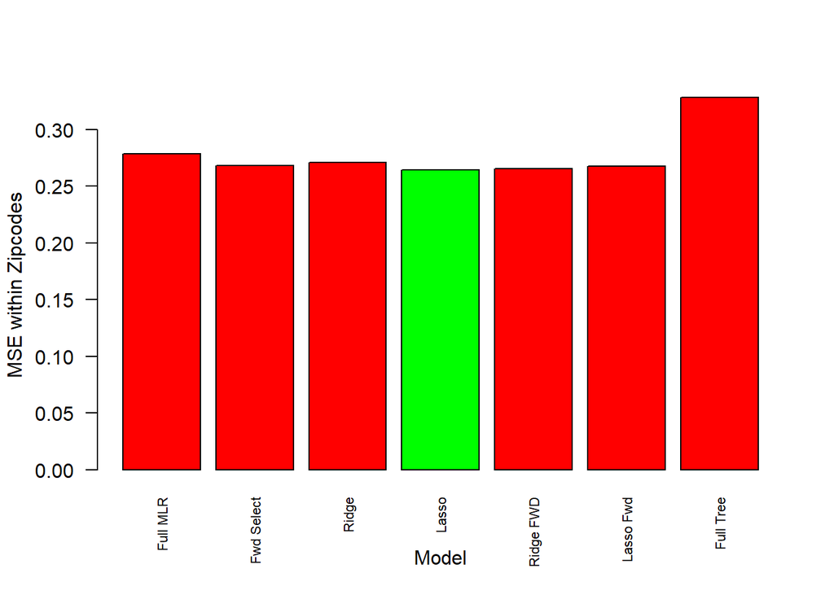

```r
color <- c(rep('Red', 3), 'Green', rep('Red', 4))
barplot(MSE_All_Same, names.arg = MSE_Name_Same, las = 2, cex.names = .7, col = color, ylab = 'MSE within Zipcodes', xlab = 'Model' )
```

```r
which.min(MSE_All_Same)
```

```
## [1] 4
```

You can see from the above graph that Lasso on all the variables has the lowest MSE and therefore explains the most variability. However, It is rather similar to the multiple linear regression model that was selected with forward selection.As such, for interpretability purposes, we might want to stick with using the forward selection model to explain variability. This model uses ur_user, ACS_TOT_POP_US_ABOVE1_ZC, ACS_PCT_MALE_ZC, ACS_PCT_FOREIGN_BORN_ZC, ACS_PCT_OTH_LANG_ZC, ACS_PCT_SPANISH_ZC, ACS_PCT_ASIAN_ZC, ACS_PCT_BLACK_ZC, ACS_PCT_HISPANIC_ZC, ACS_PCT_WHITE_ZC, ACS_PCT_HH_SMARTPHONE_ZC, ACS_PCT_HH_CELLULAR_ZC, ACS_PCT_HH_NO_INTERNET_ZC, ACS_PCT_EMPLOYED_ZC, ACS_PCT_HH_FOOD_STMP_BLW_POV_ZC, ACS_PCT_BACHELOR_DGR_ZC, ACS_PCT_DIF_STATE_ZC, ACS_PCT_DRIVE_2WORK_ZC, and ACS_PCT_HU_NO_VEH_ZC to explain approximately 79% of the variability in log(scaled_sci).